# Project for Time Series Analysis

Sylwester Kubik, Mateusz Mglej, Agnieszka Noga, Aleksandra Rewera

16.01.2025

# Task 1

- Consider the monthly numbers of passengers (file *dane_RNKM3.csv*).
- Make numbers of passengers forecasts for each month of the first half of 2025.

## Working with data

```r
data_read <- read.csv('dane_RNKM3.csv')
```

Creating a time series and its plot.

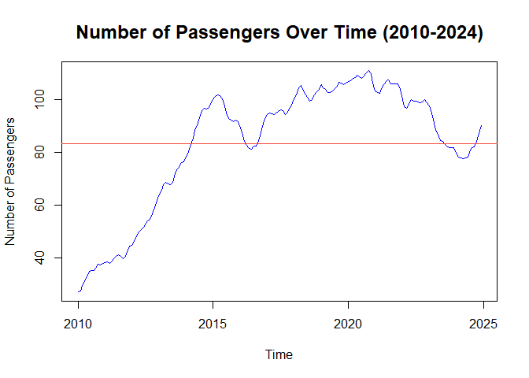

```r
data <- ts(data_read[2], start = c(2010,1), frequency = 12)

plot.ts(data,
  col = "blue",
  lwd = 1,
  main = "Number of Passengers Over Time (2010-2024)",
  xlab = "Time",
  ylab = "Number of Passengers",
  cex.main = 1.5,
  cex.lab = 1.2,
  cex.axis = 1.1)
abline(h=mean(data), col='1906', lwd = 1)
```

We notice a certain **trend**, mainly increasing, with two noticeable drops. Therefore, we assume that there is **no seasonality**.

### Box Cox transformation

```r
lamdba <- BoxCox.lambda(data)
lamdba
```

```
## [1] 1.027168
```

We obtain $\lambda \sim 1$. This means that we do not need a Box-Cox transformation.

### ACF and PACF plots

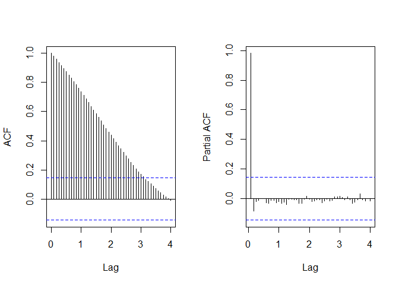

```r
par(mfrow=c(1,2))

acf(data,  main=" ",lag.max=48, ci=.95)
pacf(data, main=" ",lag.max=48, ci=.95)
```

The ACF tends to zero very slowly, so there is probably no stationarity. We can verify whether the series is stationary using *the Dickey-Fuller test*.

```r
adf.test(data)
```

```
##
##  Augmented Dickey-Fuller Test
##
## data:  data
## Dickey-Fuller = -1.6092, Lag order = 5, p-value = 0.7396
## alternative hypothesis: stationary
```

The augmented Dickey-Fuller test don’t reject null hypothesis about non-starionarity, we are in alternative, so we can assume that our data is non-stationary. Therefore, there is no need to use periodogram to check if the seasonality of data.

### Seasonality

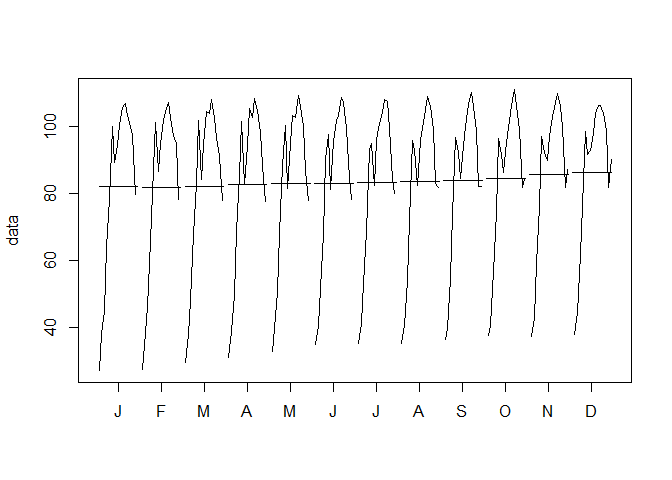

```r
monthplot(data)
```

*Monthplot* confirms that there is **no seasonality** in our time series, but we can observe a visible **trend**.

### Trend

To remove the trend, we will use the *difference operator* with $lag=1$.

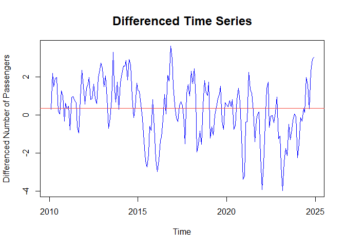

```r
D_data<-diff(data,lag=1)
plot(D_data,
  col = "blue",
  lwd = 1,
  main = "Differenced Time Series",
  xlab = "Time",
  ylab = "Differenced Number of Passengers",
  cex.main = 1.5,
  cex.lab = 1.2,
  cex.axis = 1.1)
abline(h=mean(D_data), col='1906')
```

As we can see, we effectively remove the trend. Let’s check if our modified data is stationary.

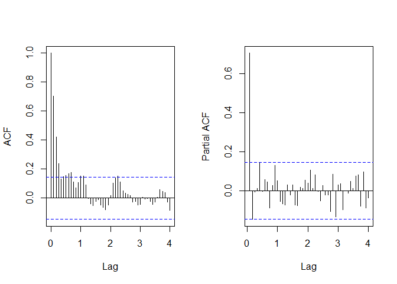

```r
par(mfrow=c(1,2))
LagMax<-48
acf(na.omit(D_data), main='', lag.max=LagMax)
pacf(na.omit(D_data), main='', lag.max=LagMax)
```

```r
adf.test(D_data)
```

```
##
##  Augmented Dickey-Fuller Test
##
## data:  D_data
## Dickey-Fuller = -3.7235, Lag order = 5, p-value = 0.02429
## alternative hypothesis: stationary
```

Both on the ACF and PACF plots, the data tends to zero. Additionally, on the ACF plot, the data tends to zero very quickly. Thus, the modified data are **stationary**, as confirmed by the Dickey-Fuller test. After three lags, the ACF values are close to 0, which may indicate that a model with $q=3$ fits this data well.

## Fitting ARIMA(0,1,q)

### ARIMA(0,1,3)

```r
model_013 <- sarima(D_data,0,1,3)
```

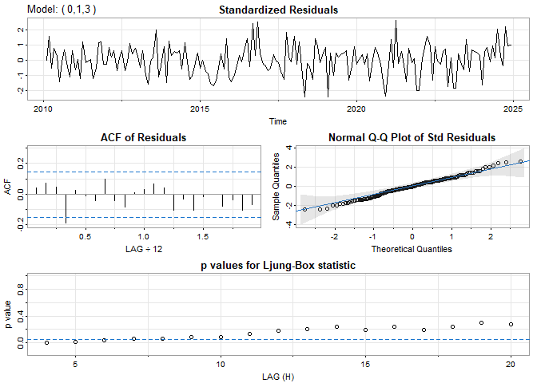

```r
model_013$ICs
```

```
##      AIC     AICc      BIC
## 3.044552 3.045851 3.133928
```

```r
model_013$ttable
```

```
##          Estimate     SE t.value p.value
## ma1       -0.1957 0.0783 -2.4983  0.0134
## ma2       -0.3478 0.1005 -3.4595  0.0007
## ma3       -0.1923 0.0802 -2.3958  0.0176
## constant   0.0022 0.0224  0.1004  0.9201
```

We can see *the constant* is not a significant parameter, so we can omit it.

### ARIMA(0,1,3) no constant

```r
model_013_nc <- sarima(D_data,0,1,3, no.constant = TRUE)
```

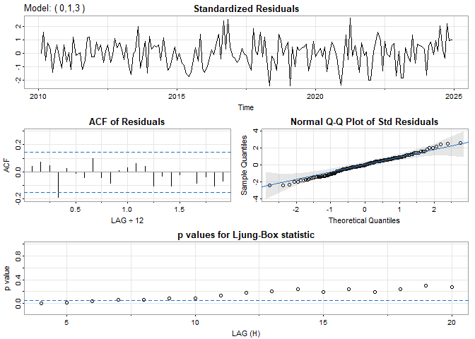

```r
model_013_nc$ICs
```

```
##      AIC     AICc      BIC
## 3.033374 3.034149 3.104875
```

```r
model_013_nc$ttable
```

```
##     Estimate     SE t.value p.value
## ma1  -0.1962 0.0783 -2.5045  0.0132
## ma2  -0.3483 0.1007 -3.4603  0.0007
## ma3  -0.1929 0.0803 -2.4028  0.0173
```

We observe that all coefficients are significantly important in explaining the residuals. Unfortunately, this model is not adequate. It does not satisfy *the residual assumption* based on the Ljung-Box test.

Let’s see the ACF and PACF plots again for modified data.

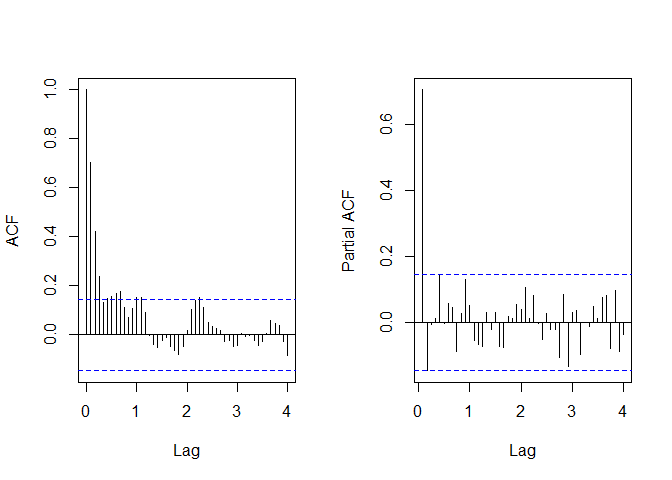

```r
par(mfrow=c(1,2))
LagMax<-48
acf(na.omit(D_data), main='', lag.max=LagMax)
pacf(na.omit(D_data), main='', lag.max=LagMax)
```

Based on above plots let’s consider such models:

- ARIMA(1,1,3)
- ARIMA(1,1,8)
- ARIMA(1,1,2)

## Fitting ARIMA(p,1,q)

### ARIMA(1,1,3)

```r
model_113 <- sarima(D_data,1,1,3, no.constant = FALSE)
```

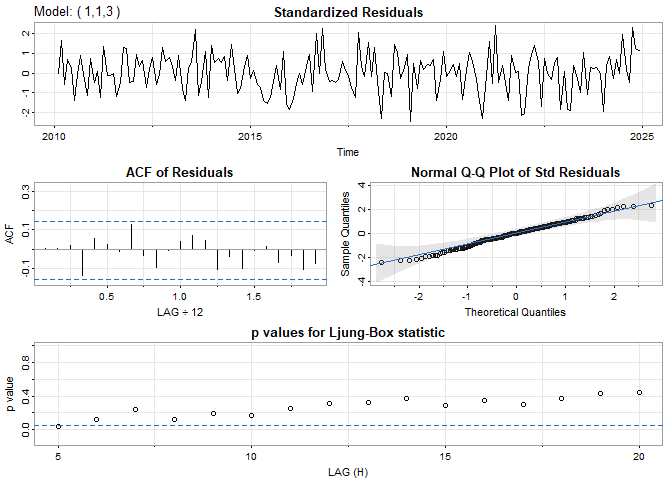

```r
model_113$ICs
```

```
##      AIC     AICc      BIC
## 3.003311 3.005271 3.110562
```

```r
model_113$ttable
```

```
##          Estimate     SE t.value p.value
## ar1        0.5370 0.1411  3.8072  0.0002
## ma1       -0.7411 0.1446 -5.1263  0.0000
## ma2       -0.2056 0.1143 -1.7980  0.0739
## ma3       -0.0533 0.1320 -0.4038  0.6869
## constant  -0.0080 0.0042 -1.9189  0.0566
```

*ma3* is not a significant coefficient in this model.

### ARIMA(1,1,8)

```r
model_118 <- sarima(D_data,1,1,8, no.constant = FALSE)
```

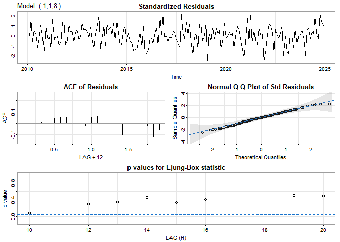

```r
model_118$ICs
```

```
##      AIC     AICc      BIC
## 3.029639 3.037040 3.226266
```

```r
model_118$ttable
```

```
##          Estimate     SE t.value p.value
## ar1       -0.2430 0.5351 -0.4541  0.6504
## ma1        0.0596 0.5295  0.1125  0.9105
## ma2       -0.3394 0.1353 -2.5083  0.0131
## ma3       -0.2936 0.1688 -1.7395  0.0838
## ma4       -0.3361 0.1378 -2.4397  0.0157
## ma5       -0.0643 0.1561 -0.4123  0.6806
## ma6       -0.0440 0.0878 -0.5017  0.6165
## ma7       -0.0698 0.0767 -0.9098  0.3642
## ma8        0.0876 0.1012  0.8656  0.3879
## constant  -0.0083 0.0038 -2.2028  0.0290
```

Here we have *7 coefficients* that are not significant in this model.

### ARIMA(1,1,2)

```r
model_112 <- sarima(D_data,1,1,2, no.constant = FALSE)
```

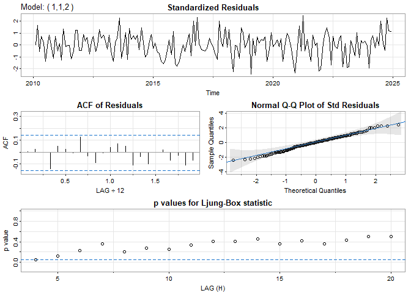

```r
model_112$ICs
```

```
##      AIC     AICc      BIC
## 2.992958 2.994257 3.082334
```

```r
model_112$ttable
```

```
##          Estimate     SE t.value p.value
## ar1        0.5788 0.0900  6.4328  0.0000
## ma1       -0.7798 0.1061 -7.3523  0.0000
## ma2       -0.2202 0.1049 -2.0991  0.0373
## constant  -0.0079 0.0043 -1.8608  0.0645
```

In this model only *constant* is no significant coefficient. Now, let’s check model without constant.

### ARIMA(1,1,2) no constant

```r
model_112_nc <- sarima(D_data,1,1,2, no.constant = TRUE)
```

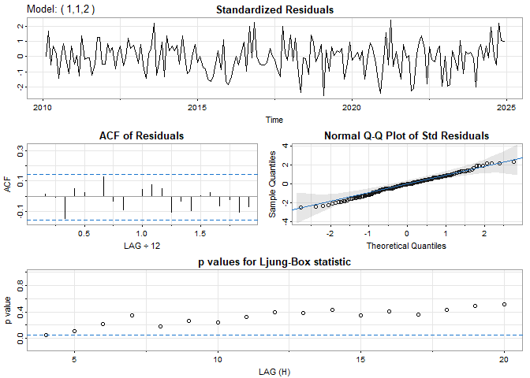

```r
model_112_nc$ICs
```

```
##      AIC     AICc      BIC
## 2.993758 2.994533 3.065259
```

```r
model_112_nc$ttable
```

```
##     Estimate     SE t.value p.value
## ar1   0.5888 0.0961  6.1262   0.000
## ma1  -0.7635 0.1118 -6.8290   0.000
## ma2  -0.2090 0.1031 -2.0284   0.044
```

In this model *every coefficient is important*.

### Summary

```r
model_112$ICs
```

```
##      AIC     AICc      BIC
## 2.992958 2.994257 3.082334
```

```r
model_112$ttable
```

```
##          Estimate     SE t.value p.value
## ar1        0.5788 0.0900  6.4328  0.0000
## ma1       -0.7798 0.1061 -7.3523  0.0000
## ma2       -0.2202 0.1049 -2.0991  0.0373
## constant  -0.0079 0.0043 -1.8608  0.0645
```

```r
model_112_nc$ICs
```

```
##      AIC     AICc      BIC
## 2.993758 2.994533 3.065259
```

```r
model_112_nc$ttable
```

```
##     Estimate     SE t.value p.value
## ar1   0.5888 0.0961  6.1262   0.000
## ma1  -0.7635 0.1118 -6.8290   0.000
## ma2  -0.2090 0.1031 -2.0284   0.044
```

The model quality coefficients indicate that *ARIMA(1,1,2) no constant* is slightly better. Therefore, we will also select this model for prediction.

## Forecasting using *sarima.for* function

Let’s remind our time series.

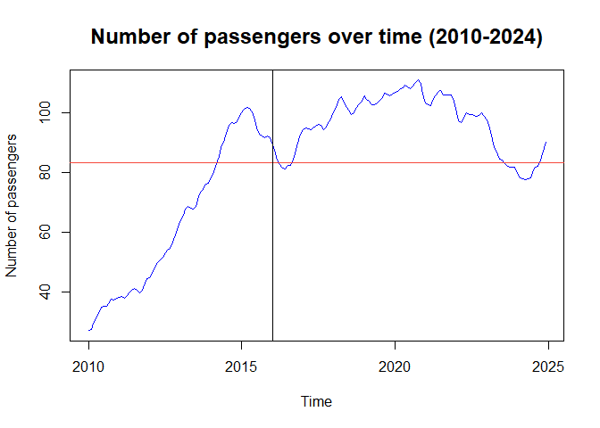

```r
plot.ts(data,
  col = "blue",
  lwd = 1,
  main = "Number of passengers over time (2010-2024)",
  xlab = "Time",
  ylab = "Number of passengers",
  cex.main = 1.5,
  cex.lab = 1.2,
  cex.axis = 1.1)
abline(v=2016, h=mean(data), col=c('1906','2025'))
```

Using sarima.for function for data based on ARIMA(1,1,2) without constant.

```r
pred <- sarima.for(data, n.ahead=6,1,1,2, no.constant = TRUE)
```

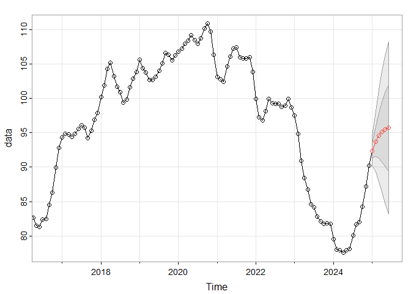

Prediction and confidence levels based of standard errors.

```r
future <- data.frame(se_min=pred$pred-pred$se, prediction=pred$pred,
                    se_max=pred$pred+pred$se)

future <- ts(future, start = c(2025,1), frequency = 12)

future
```

```
##            se_min prediction    se_max
## Jan 2025 91.30100   92.35337  93.40574
## Feb 2025 91.51637   93.71146  95.90656
## Mar 2025 91.25291   94.57364  97.89437
## Apr 2025 90.74452   95.12100  99.49747
## May 2025 90.11770   95.46848 100.81927
## Jun 2025 89.44251   95.68909 101.93567
```

Comparing both plots we should remember that the Y-axes differ for each plot (the scales are different). As we expected, the prediction shows an increasing trend. The Sarima.for function returns a list of predictions and standard errors.

# Task 2

- Consider the Mateusz’s time series from Lab 1 task 4.2 (i.e wind speed in Delhi from 1st January 2013 to 1st January 2017)
- Plot the periodogram. How can a periodogram be used to transform your data?
- Make all necessary transformations to get a stationary time series (noise).
- If possible, choose the ARMA (p, q) model for stationary noise.

## Loading data

```r
data_read <- read.csv('DailyDelhiClimateTrain.csv')

data <- ts(data_read$wind_speed, start = c(2013,1,1), frequency = 365)
```

## Working with data

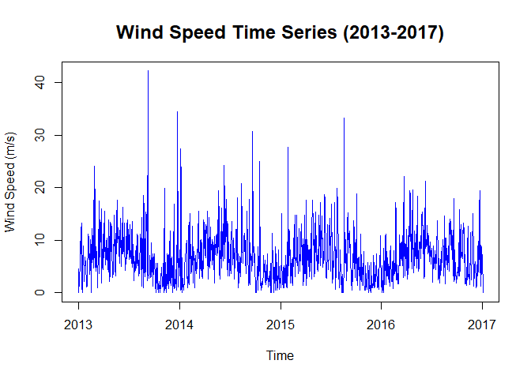

```r
plot.ts(data,
  col = "blue",
  lwd = 1,
  main = "Wind Speed Time Series (2013-2017)",
  xlab = "Time",
  ylab = "Wind Speed (m/s)",
  cex.main = 1.5,
  cex.lab = 1.2,
  cex.axis = 1.1)
```

This time series shows daily wind speed in Delhi from 1st January 2013 to 1st January 2017.

We can observe some trend - more wind in summertime and some strange values (for example one over 40 kmph in 2013).

### ACF i PACF

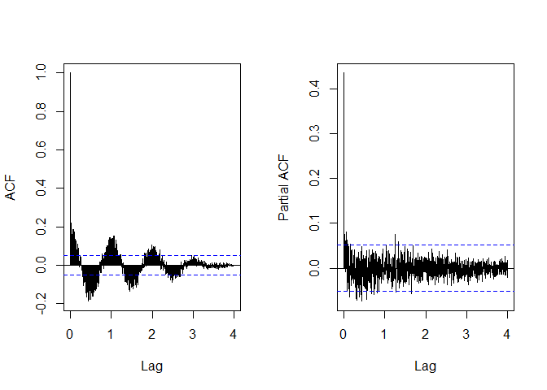

```r
par(mfrow=c(1,2))
LagMax <- 365*4
acf(data,  main=" ",lag.max=LagMax, ci=.95)
pacf(data, main=" ",lag.max=LagMax, ci=.95)
```

The plots show that there is seasonality in data. Let’s check stationarity with Dickey-Fuller test.

```r
adf.test(data)
```

```
##
##  Augmented Dickey-Fuller Test
##
## data:  data
## Dickey-Fuller = -7.1185, Lag order = 11, p-value = 0.01
## alternative hypothesis: stationary
```

Test reject null hypothesis of non-stationarity. Our data is stationary.

### Periodogram

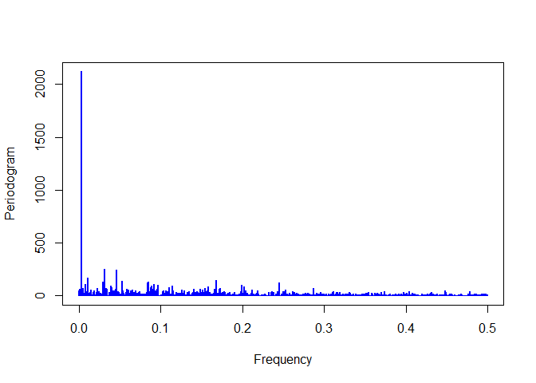

```r
par(mfrow=c(1,1))
n = length(data)
Per= Mod(fft(data-mean(data)))^2/n
Freq = (1:(n/2) -1)/n
plot(Freq[1:(n/2)], Per[1:(n/2)], type='h', lwd=2, ylab="Periodogram",
     xlab="Frequency", col="blue")
```

```r
nn=n/2
u = which.max(Per[1:nn])
uu = which.max(Per[1:nn][-u])

u; 1/Freq[u]
```

```
## [1] 5
```

```
## [1] 365.5
```

```r
uu; 1/Freq[uu]
```

```
## [1] 46
```

```
## [1] 32.48889
```

We can see that we have annual seasonality.

### Seasonality

To remove the seasonality, we will use the difference operator with lag=365.

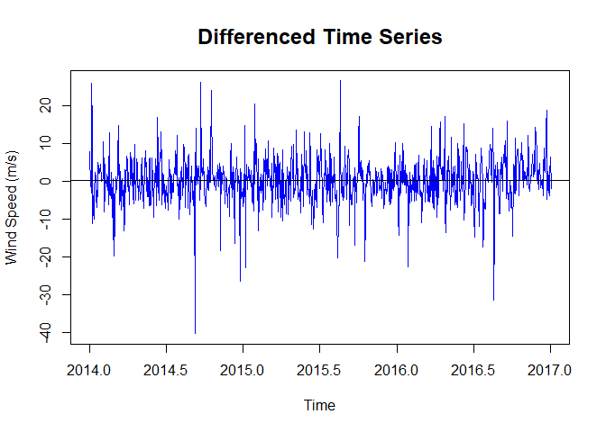

```r
D_data<-diff(data,lag=365)
plot(D_data,
  col = "blue",
  lwd = 1,
  main = "Differenced Time Series",
  xlab = "Time",
  ylab = "Wind Speed (m/s)",
  cex.main = 1.5,
  cex.lab = 1.2,
  cex.axis = 1.1)
abline(h=mean((D_data)))
```

The annual seasonality has been effectively removed.

ACF i PACF plots for modified data

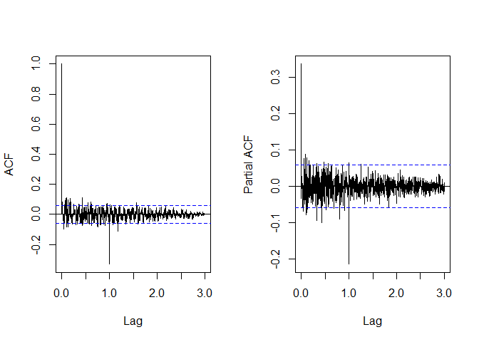

```r
par(mfrow=c(1,2))
acf(na.omit(D_data), main='', lag.max=LagMax)
pacf(na.omit(D_data), main='', lag.max=LagMax)
```

### Trend

Now we will remove the trend.

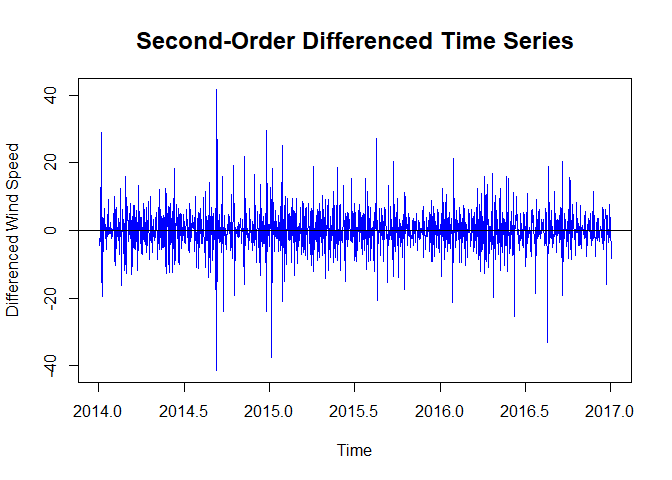

```r
par(mfrow=c(1,1))
DD_data<-diff(D_data,lag=1)
plot(DD_data,
  col = "blue",
  lwd = 1,
  main = "Second-Order Differenced Time Series",
  xlab = "Time",
  ylab = "Differenced Wind Speed",
  cex.main = 1.5,
  cex.lab = 1.2,
  cex.axis = 1.1)
abline(h=mean(DD_data))
```

We can see that there is only noise, without trend and without previously removed seasonality.

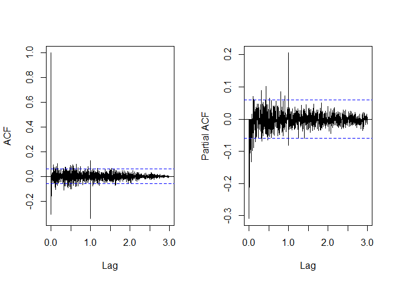

```r
par(mfrow=c(1,2))
acf(na.omit(DD_data), main='', lag.max=LagMax)
pacf(na.omit(DD_data), main='', lag.max=LagMax)
```

After lag = 1, the data tends to zero. We will check if the modified data is stationary.

```r
adf.test(DD_data)
```

```
##
##  Augmented Dickey-Fuller Test
##
## data:  DD_data
## Dickey-Fuller = -16.289, Lag order = 10, p-value = 0.01
## alternative hypothesis: stationary
```

So this data is stationary.

## Fitting models to noise

### ARMA(1,0)

```r
par(mfrow=c(1,1))
model_100 <- sarima(DD_data, 1,0,0, no.constant = TRUE)
```

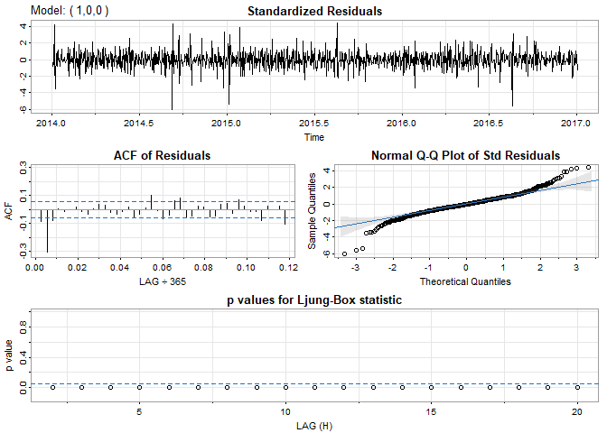

```r
model_100$ICs
```

```
##      AIC     AICc      BIC
## 6.610564 6.610568 6.619687
```

```r
model_100$ttable
```

```
##     Estimate     SE  t.value p.value
## ar1  -0.3092 0.0287 -10.7594       0
```

### ARMA(0,1)

```r
par(mfrow=c(1,1))
model_001 <- sarima(DD_data, 0,0,1, no.constant = TRUE)
```

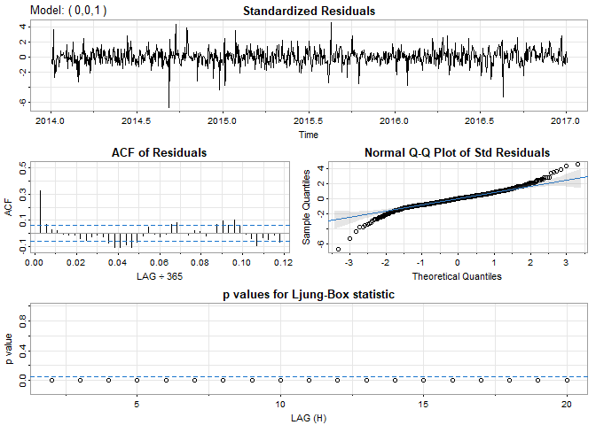

```r
model_001$ICs
```

```
##      AIC     AICc      BIC
## 6.428293 6.428296 6.437416
```

```r
model_001$ttable
```

```
##     Estimate     SE   t.value p.value
## ma1  -0.9883 0.0058 -169.9331       0
```

### ARMA(1,1)

```r
par(mfrow=c(1,1))
model_101 <- sarima(DD_data, 1,0,1)
```

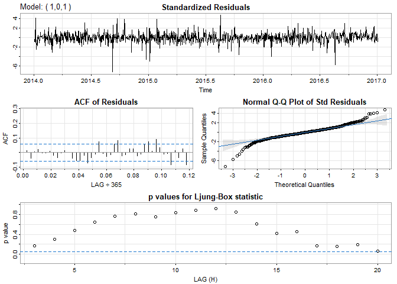

```r
model_101$ICs
```

```
##      AIC     AICc      BIC
## 6.315583 6.315603 6.333829
```

```r
model_101$ttable
```

```
##       Estimate     SE   t.value p.value
## ar1     0.3341 0.0285   11.7191  0.0000
## ma1    -1.0000 0.0050 -199.5799  0.0000
## xmean   0.0012 0.0008    1.5341  0.1253
```

### ARMA(1,1) without constant

```r
par(mfrow=c(1,1))
model_101_nc <- sarima(DD_data, 1,0,1, no.constant = TRUE)
```

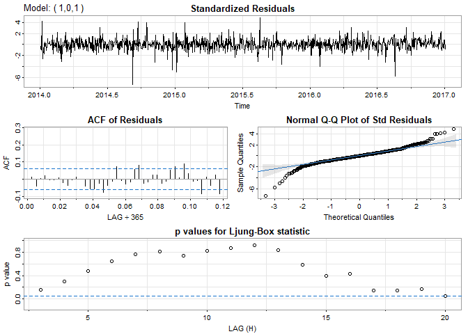

```r
model_101_nc$ICs
```

```
##      AIC     AICc      BIC
## 6.315212 6.315222 6.328897
```

```r
model_101_nc$ttable
```

```
##     Estimate     SE   t.value p.value
## ar1   0.3330 0.0289   11.5340       0
## ma1  -0.9956 0.0042 -237.1426       0
```

## Summary

From the constructed models, it follows that model **ARMA(1,1) without mean** is the best. All variables used in this model are significantly important and the assumptions about residuals are satisfied.